# Astroestadística

## Modelo de Regresión Final

Como primer paso, voy a eliminar la variable NO2, de acuerdo al análisis previo que hicimos sobre la misma.

```r
model.benceno2 <- lm(Benceno~CO+NOx, data = datos_norm)
summary(model.benceno2)
```

```
##
## Call:
## lm(formula = Benceno ~ CO + NOx, data = datos_norm)
##
## Residuals:
##     Min      1Q  Median      3Q     Max
## -2.4794 -0.3768  0.0264  0.3659  4.1055
##
## Coefficients:
##             Estimate Std. Error t value Pr(>|t|)
## (Intercept) 1.880146   0.042911  43.815   <2e-16 ***
## CO          1.616019   0.014347 112.635   <2e-16 ***
## NOx         0.013998   0.006197   2.259   0.0239 *
## ---
## Signif. codes:  0 '***' 0.001 '**' 0.01 '*' 0.05 '.' 0.1 ' ' 1
##
## Residual standard error: 0.5946 on 6938 degrees of freedom
## Multiple R-squared:  0.8312, Adjusted R-squared:  0.8312
## F-statistic: 1.708e+04 on 2 and 6938 DF,  p-value: < 2.2e-16
```

Veamos ahora si mejoraron los gráficos de diagnóstico del modelo.

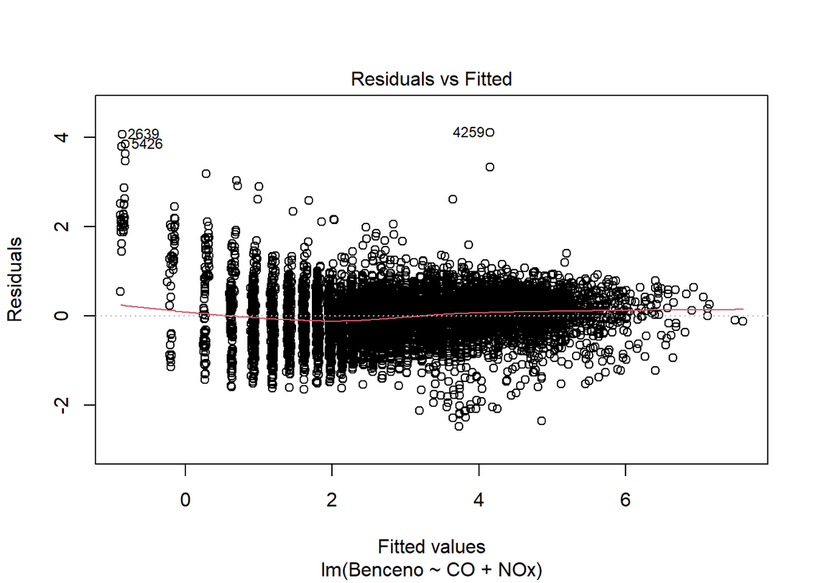

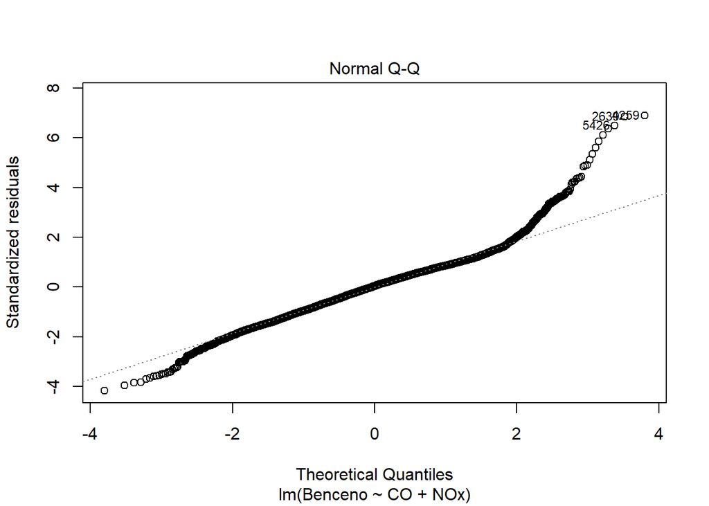

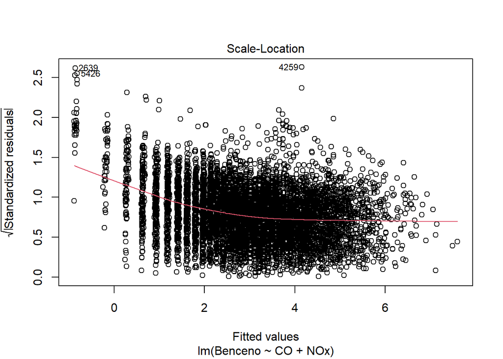

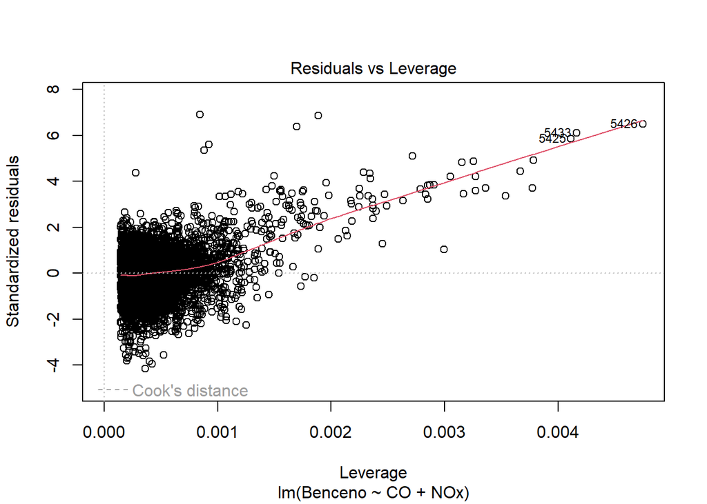

```r
plot(model.benceno2)
```

Los gráficos son aparentemente idénticos a los del primer modelo.

Veamos si podemos refinar un poco más el modelo mediante el análisis de valores atípicos o influyentes.

Generamos el diagrama de caja y brazos para los datos.

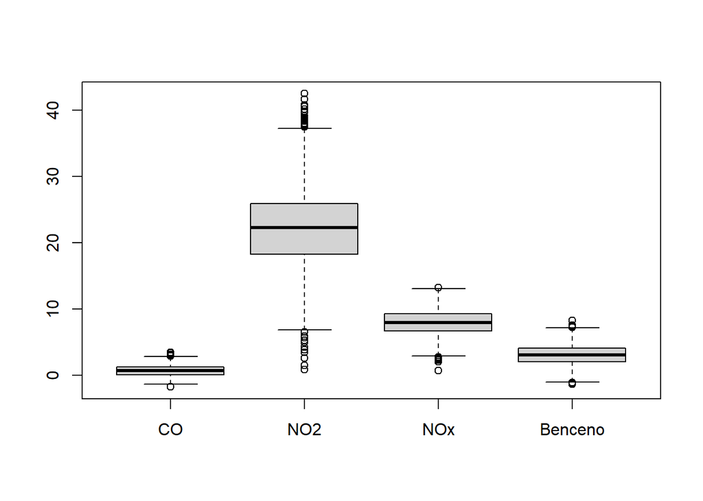

```r
boxplot.matrix(as.matrix(datos_norm),use.cols = T)
```

Como podemos ver, si existen unos cuantos valores atípicos en nuestros datos (recordemos que en este punto sólo nos interesan los que corresponden a CO y NOx).

Identificamos los outliers con ayuda de la función outlierTest

```r
library(car)
atipicos <- outlierTest(model.benceno2)
renglones_atipicos <- as.integer(names(atipicos$rstudent))
print(atipicos)
```

```
##      rstudent unadjusted p-value Bonferroni p
## 4259 6.930907         4.5580e-12   3.1637e-08
## 2639 6.877580         6.6188e-12   4.5941e-08
## 5426 6.517387         7.6560e-11   5.3140e-07
## 2640 6.395812         1.7008e-10   1.1805e-06
## 5433 6.132302         9.1372e-10   6.3422e-06
## 5425 5.869612         4.5696e-09   3.1718e-05
## 4258 5.619098         1.9940e-08   1.3841e-04
## 2638 5.358547         8.6593e-08   6.0104e-04
## 5427 5.121614         3.1110e-07   2.1593e-03
## 5416 4.924167         8.6679e-07   6.0164e-03
```

Creamos el nuevo dataframe quitando lo datos atípicos (En este paso iteré varias veces eliminando combinaciones de los datos atípicos, hasta que encontré una que mejoró levemente los parámetros del modelo)

```r
# Número de renglones a remover
datos_norm_2 <- datos_norm[-c(2638, 2639, 2640), ]

model.benceno3 <- lm(Benceno~CO+NOx, data = datos_norm_2)
summary(model.benceno3)
```

```
##
## Call:
## lm(formula = Benceno ~ CO + NOx, data = datos_norm_2)
##
## Residuals:
##     Min      1Q  Median      3Q     Max
## -2.4824 -0.3748  0.0270  0.3657  4.1080
##
## Coefficients:
##             Estimate Std. Error t value Pr(>|t|)
## (Intercept) 1.887311   0.042564  44.341   <2e-16 ***
## CO          1.624823   0.014253 114.002   <2e-16 ***
## NOx         0.012164   0.006148   1.979   0.0479 *
## ---
## Signif. codes:  0 '***' 0.001 '**' 0.01 '*' 0.05 '.' 0.1 ' ' 1
##
## Residual standard error: 0.5897 on 6935 degrees of freedom
## Multiple R-squared:  0.8341, Adjusted R-squared:  0.834
## F-statistic: 1.743e+04 on 2 and 6935 DF,  p-value: < 2.2e-16
```

Cómo podemos ver, nuestro $R^2$ subió de 0.8312 a 0.834. El valor de Pr(>|t|) subió un poco de 0.0239 a 0.0479, pero logramos mantenerlo por debajo de 0.05.

El error estándar del modelo bajó un poco, de 0.5946 a 0.5897.

Veamos lo que ocurrió con los coeficientes y sus errores.

```r
coeficientes <- coef(model.benceno3)  # Coeficientes estimados
std_errors <- sqrt(diag(vcov(model.benceno3)))  # Errores estándar

# Cálculo de los errores porcentuales
errores_porcentuales <- (std_errors / coeficientes) * 100

mostrar_errores <- data.frame(coeficientes, std_errors, errores_porcentuales, check.names = TRUE)
print(mostrar_errores)
```

```
##             coeficientes  std_errors errores_porcentuales
## (Intercept)   1.88731132 0.042563617            2.2552515
## CO            1.62482292 0.014252602            0.8771788
## NOx           0.01216435 0.006148106           50.5420128
```

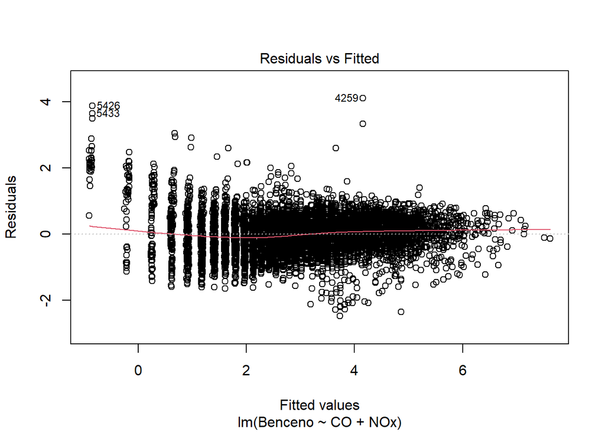

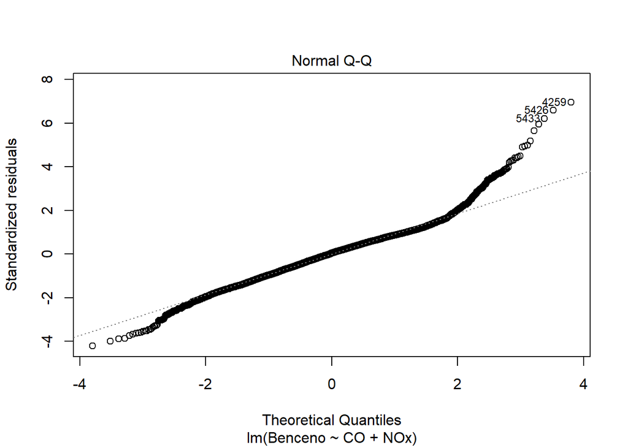

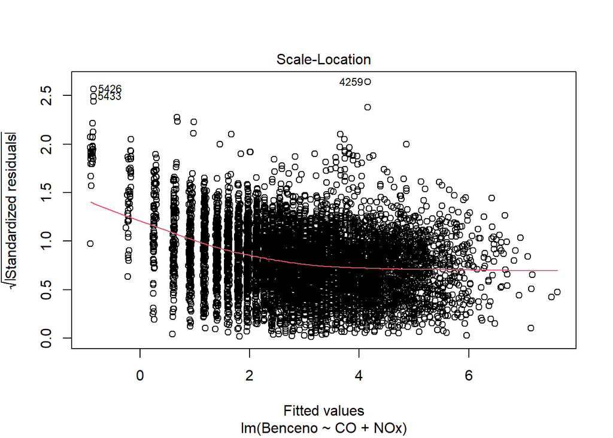

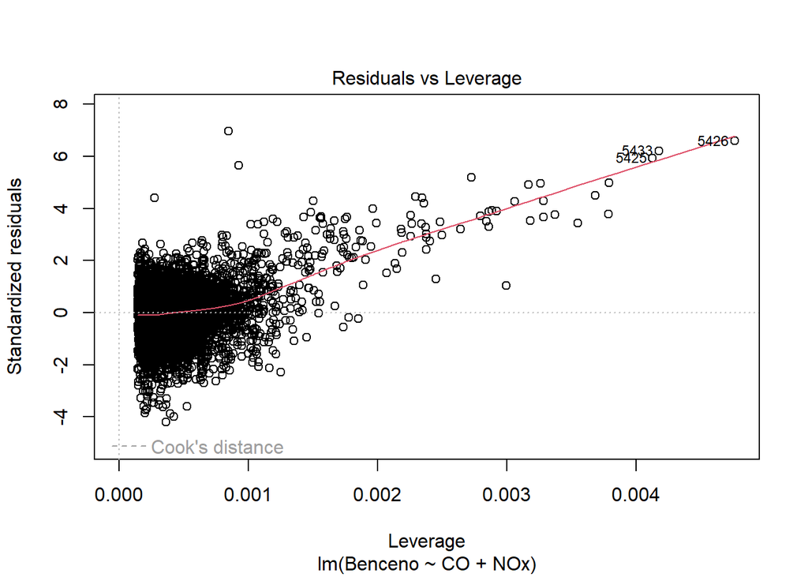

```r
plot(model.benceno3)
```

El diagnóstico del modelo mediante las gráficas de la función plot no presenta cambios significativos respecto al modelo 2.

Para terminar esta parte, la ecuación del modelo final es:

#### $B = 1.88731132 + 1.62482292CO + 0.01216435NOx$

## Conclusiones

¿Por qué es esto importante? Como vimos desde la Fase 2 y podemos comprobar facilmente al explorar los datos originales, el dispositivo multisensorial NO cuenta con un sensor dedicado a medir las concentraciones de Benceno en la atmósfera, pero si tiene sensores para medir CO y NOx, por lo que podría realizar una estimación razonablemente confiable de la cantidad de Benceno a partir de estas mediciones.

Una detalle importante que debemos tomar en cuenta es que tuvimos que eliminar las columnas de NMHC de referencia, pues la mayoría de los registros eran datos faltantes. Quizá podríamos haber refinado aún más la precisión del modelo al incluir NMHC al conjunto de predictores. Una posibilidad para verificar esto usando los datos de este mismo dadaset es tomar en cuenta únicamente los registros para los primeros dos meses del experimento pues, tal y como vimos en la Fase 2, en este periodo sí contamos con registros para la estación de referencia.

Por otro lado, existe la posibilidad de que el comportamiento un tanto atípico de los registros de NO2 (que ya estudiamos en la Fase 2) puede haber influido en el hecho de que tuvimos que eliminar esta variable del modelo final. Nuevamente, queda la sugerencia de extender el análisis incluyendo las variables categóricas de tiempo que propuse en la Fase 2 y verificar si esto ayudaría a mejorar la precisión del modelo.